# An overview on rankinma

Enoch Kang, Chiehfeng Chen Wen-Hsuan Hou, Jin-Hua Chen, Yu-Chieh Chuang, & Edwin Chan

April 01, 2024

[figure not shown]

[figure not shown]

## Brief overview

Package *rankinma* supports users to easily obtain and visualize various metrics of treatment ranking from network meta-analysis no matter using frequentist or Bayesian approach. This package not only accepts manual-prepared data set of treatment ranking metrics from users, but also can help users to gather various treatment ranking metrics in network meta-analysis. Users can use functions in *rankinma* by calling the library with following syntax:

```r
library(rankinma)
```

## Feature

*rankinma* allows users to visualize various treatment ranking metrics in network meta-analysis based either common-effect model or random-effects model. The current version includes three common metrics of treatment ranking.

- **Probabilities:** probabilities of every available treatment on each possible rank.
- **SUCRA:** the value of surface under the cumulative ranking curve using Bayesian approach.
- **P-score:** the value of SUCRA using frequentist approach.

- **Beading plot:** a novel graphics for displaying global metrics of treatment ranking (i.e. SUCRA, P-score, and P-best) based on numeric line plot.
- **Bar chart:** a classic graphics for most metrics of treatment ranking (i.e. probabilities, SUCRA, and P-score), and *rankinma* supports two sub-type of bar chart in terms of side-by-side bar chart and cumulative bar chart.
- **Line chart:** a classic graphics for most metrics of treatment ranking (i.e. probabilities, SUCRA, and P-score), and *rankinma* supports two sub-type of line chart in terms of simple line chart (a line on a chart) and composite line chart (multiple lines on a chart).
- **Heat plot:** a new graphics for showing global metrics of treatment ranking (i.e. SUCRA and P-score) for each outcome, and *rankinma* supports to gather all heat plots of outcomes with interests on a plot.
- **Spie chart:** a new graphics proposed in 2020 for displaying multiple global metrics of treatment ranking (i.e. SUCRA and P-score) from outcomes with interests by each treatment, and *rankinma* supports to place all spie charts on a plot.

## Flow and functions

Users can visualize treatment ranking after network meta-analysis in five steps, but have to check condition before using *rankinma*.

**Situation 1:** Users have data for network meta-analysis of **a single outcome** but do not get treatment ranking metrics yet.

**Situation 2:** Users have data for network meta-analysis of **various outcomes** but do not get treatment ranking metrics yet.

#### For situation 1:

**Step 1.** Load data and do network meta-analysis.

**Step 2.** Get treatment ranking metrics from the network meta-analysis using function `GetMetrics()`.

**Step 3.** Setup data in *rankinma* format using function `SetMetrics()`.

**Step 4.** Visualization using function `PlotBeads()`, `PlotHeat()`, `PlotBar()`, or `PlotLine()`.

#### For situation 2:

**Step 1.** Load data and do network meta-analysis.

**Step 2.** Get treatment ranking metrics from the network meta-analysis using function `GetMetrics()`.

— Repeat step 1 and 2 for each outcome, and keep output of them for the further steps. —

**Step 3.** Combine treatment ranking metrics using function `rbind()` in R *base*.

**Step 4.** Setup data in *rankinma* format using function `SetMetrics()`.

**Step 5.** Visualization using function `PlotBeads()`, `PlotHeat()`, `PlotBar()`, or `PlotLine()`.

## Usage and examples

The following steps and syntax demonstrate how user can illustrate a summary of treatment ranking metrics on various outcomes from network meta-analysis.

Example 1 for illustrating line chart when users have data for network meta-analysis of a single outcome but do not get treatment ranking metrics yet.

**STEP 1.** Load data

```r
library(rankinma)
library(netmeta)
data(Senn2013)
nmaOutput <- netmeta(TE,
                     seTE,
                     treat1,
                     treat2,
                     studlab,
                     data = Senn2013,
                     sm = "SMD")
```

**STEP 2.** Get Probabilities

```r
dataMetrics <- GetMetrics(nmaOutput,
                          outcome = "HbA1c.random",
                          prefer = "small",
                          metrics = "Probabilities",
                          model = "random",
                          simt = 1000)
```

**STEP 3.** Set data for rankinma

```r
dataRankinma <- SetMetrics(dataMetrics,
                           tx = tx,
                           outcome = outcome,
                           metrics.name = "Probabilities")
```

**STEP 4.** Visualize the probabilities of treatments among possible ranks

If the users wish to visualize the information using line chart, the following syntax could be a reference.

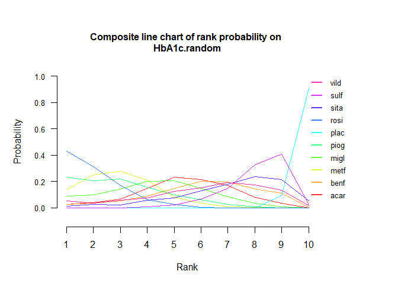

**Figure 1**. Composite line chart for probabilities of treatments on each rank.

```r
PlotLine(data = dataRankinma,
         compo = TRUE)
```

If the users wish to visualize the information using stacked bar chart, the following syntax could be a reference.

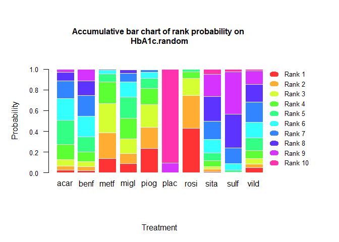

**Figure 2**. Accumulative bar chart for probabilities of treatments on each rank.

```r
PlotBar(data = dataRankinma,
        accum = TRUE)
```

Example 2 for illustrating beading plot when users have data for network meta-analysis of multiple outcomes but do not get treatment ranking metrics yet.

**STEP 1.** Load data

```r
library(rankinma)
library(netmeta)
data(Senn2013)
nmaOutput <- netmeta(TE,
                     seTE,
                     treat1,
                     treat2,
                     studlab,
                     data = Senn2013,
                     sm = "SMD")
```

**STEP 2.** Get global metrics Due to several rank metrics in network meta-analysis, users have to decide which global metric would be used in the analysis; accordingly users choose argument for parameter `metrics` in the function `GetMetrics()`. The following syntax is for users who would like to obtain the Surface Under the Cumulative Ranking Curve (SUCRA).

*Get SUCRA*

```r
nmaRandom <- GetMetrics(nmaOutput,
                        outcome = "HbA1c.random",
                        prefer = "small",
                        metrics = "SUCRA",
                        model = "random",
                        simt = 1000)
nmaCommon <- GetMetrics(nmaOutput,
                        outcome = "HbA1c.common",
                        prefer = "small",
                        metrics = "SUCRA",
                        model = "common",
                        simt = 1000)
```

If users wish to obtain the P-score, they can utilize the following syntax.

*Get P-score*

```r
nmaRandom <- GetMetrics(nmaOutput,
                        outcome = "HbA1c.random",
                        prefer = "small",
                        metrics = "P-score",
                        model = "random",
                        simt = 1000)
nmaCommon <- GetMetrics(nmaOutput,
                        outcome = "HbA1c.common",
                        prefer = "small",
                        metrics = "P-score",
                        model = "common",
                        simt = 1000)
```

If users wish to obtain the P-best, they can assign the argument `P-best` to the parameter `metrics` in the function `GetMetrics()`. The following syntax is for reference.

*Get P-best*

```r
nmaRandom <- GetMetrics(nmaOutput,
                        outcome = "HbA1c.random",
                        prefer = "small",
                        metrics = "P-best",
                        model = "random",
                        simt = 1000)
nmaCommon <- GetMetrics(nmaOutput,
                        outcome = "HbA1c.common",
                        prefer = "small",
                        metrics = "P-best",
                        model = "common",
                        simt = 1000)
```

**STEP 3.** Combine metrics from multiple outcomes

```r
dataMetrics <- rbind(nmaRandom, nmaCommon)
```

**STEP 4.** Set data for rankinma As mentioned above, users choose argument for parameter `metrics` in the function `GetMetrics()` according to which global metric would be used in analysis due to several rank metrics in network meta-analysis. The following syntax is for users who would like to use SUCRA.

*Set data based on SUCRA*

```r
dataRankinma <- (dataMetrics,
                 tx = tx,
                 outcome = outcome,
                 metrics = SUCRA,
                 metrics.name = "SUCRA")
```

*Set data based on P-score*

```r
dataRankinma <- (dataMetrics,
                 tx = tx,
                 outcome = outcome,
                 metrics = P.score,
                 metrics.name = "P-score")
```

*Set data based on P-best*

```r
dataRankinma <- (dataMetrics,
                 tx = tx,
                 outcome = outcome,
                 metrics = P.best,
                 metrics.name = "P-best")
```

**STEP 5.** Visualize global ranking metrics

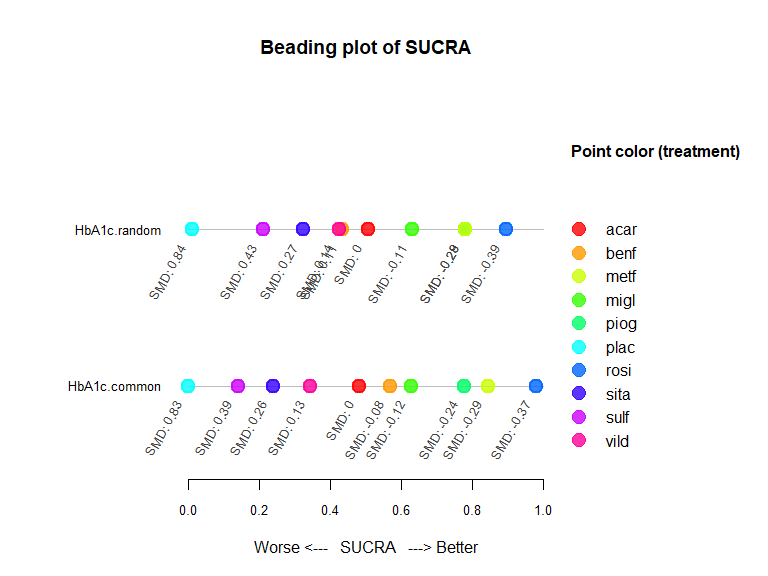

**Figure 3A**. Beading plot for SUCRA on two outcomes

```r
PlotBeads(data = dataRankinma)
```

*Illustrate beading plot sorted by P-score (with relative effects and equidistant by rank)*

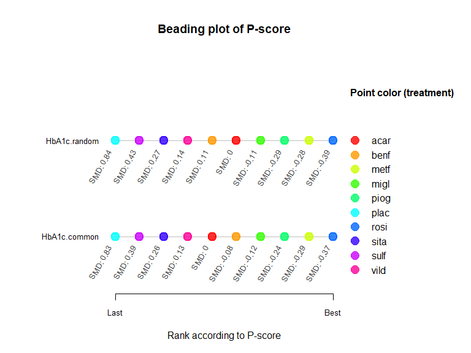

```r
PlotBeads(data = dataRankinma,
          scaleX = "Rank",
          txtValue = "Effects")
```

*Illustrate colorblind-friendly beading plot based on P-best*

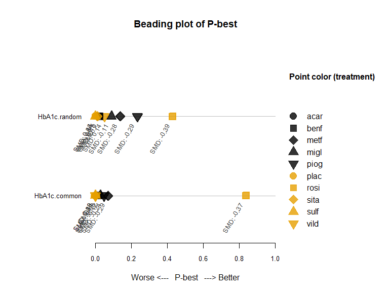

```r
PlotBeads(data = dataRankinma,
          lgcBlind = TRUE)
```

*Illustrate spie plot based on P-score*

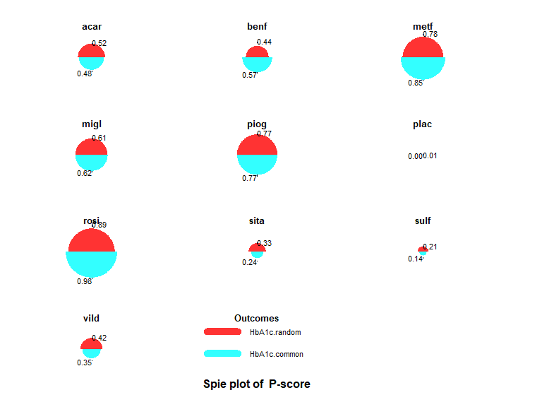

**Figure 3B**. Spie plot for P-score on two outcomes

```r
PlotSpie(data = dataRankinma)
```

## Reference

Salanti, G., Ades, A. E., & Ioannidis, J. P. (2011). Graphical methods and numerical summaries for presenting results from multiple-treatment meta-analysis: an overview and tutorial. **Journal of clinical epidemiology**, *64(2)*, 163-171.

Chaimani, A., Higgins, J. P., Mavridis, D., Spyridonos, P., & Salanti, G. (2013). Graphical tools for network meta-analysis in STATA. **PloS one**, *8(10)*, e76654.

Van Valkenhoef, G., Tervonen, T., Zwinkels, T., De Brock, B., & Hillege, H. (2013). ADDIS: a decision support system for evidence-based medicine. **Decision Support Systems**, *55(2)*, 459-475.

Rücker, G., & Schwarzer, G. (2015). Ranking treatments in frequentist network meta-analysis works without resampling methods. **BMC medical research methodology**, *15(1)*, 1-9.

Daly, C. H., Mbuagbaw, L., Thabane, L., Straus, S. E., & Hamid, J. S. (2020). Spie charts for quantifying treatment effectiveness and safety in multiple outcome network meta-analysis: a proof-of-concept study. **BMC Medical Research Methodology**, *20*, 1-13.

Balduzzi, S., Rücker, G., Nikolakopoulou, A., Papakonstantinou, T., Salanti, G., Efthimiou, O., & Schwarzer, G. (2023). netmeta: An R package for network meta-analysis using frequentist methods. **Journal of Statistical Software**, *106*, 1-40.